# 13 Agricultural fields

Satellite images are widely used for land cover classification and various related measurements within agricultural fields, especially when the size of these fields is large or when physical access is limited. In this chapter, we will illustrate the use of spectral indices derived from a Sentinel-2 image to streamline the measurements of area and perimeter in a large agricultural field in Brazil.

**TOOLS COVERED:** `Proj`, `Map`, `SpectralIndex`, `ModeFilter`, `Potrace`, `describe`, `boundingbox`, `crs`, `utmsouth`, `spectralindices`, `spectralbands`, `area`, `perimeter`, `viewer`

**MODULES:**

```julia
# framework
using GeoStats

# IO modules
using GeoIO

# viz modules
import CairoMakie as Mke
```

## 13.1 Data

We will use an image from the [Harmonized Sentinel-2 MSI](https://developers.google.com/earth-engine/datasets/catalog/COPERNICUS_S2_SR_HARMONIZED) dataset, downloaded within a box of latitude and longitude values after cloud removal and averaging between dates 2025-07-01 and 2025-07-30:

```julia
image = GeoIO.load("data/sentinel.tif")

describe(image)
```

```
Table with 7 columns and 26 rows:
      variable   scitype     mean         minimum  median   maximum  nmissing
    ┌────────────────────────────────────────────────────────────────────────
 1  │ channel1   Continuous  0.0332992    0.01038  0.02452  0.15836  0
 2  │ channel2   Continuous  0.0458128    0.01116  0.03078  0.40272  0
 3  │ channel3   Continuous  0.0732396    0.01856  0.05442  0.44634  0
 4  │ channel4   Continuous  0.0909339    0.00962  0.05076  0.49242  0
 5  │ channel5   Continuous  0.141997     0.01318  0.10734  0.65922  0
 6  │ channel6   Continuous  0.225289     0.01278  0.21972  0.62082  0
 7  │ channel7   Continuous  0.258586     0.01566  0.256    0.6173   0
 8  │ channel8   Continuous  0.273911     0.01678  0.2703   0.54794  0
 9  │ channel9   Continuous  0.292085     0.01668  0.28738  0.66534  0
 10 │ channel10  Continuous  0.293514     0.08984  0.2873   0.45494  0
 11 │ channel11  Continuous  0.266769     0.0211   0.20602  1.0866   0
 12 │ channel12  Continuous  0.160049     0.01256  0.10788  1.03716  0
 13 │ channel13  Continuous  0.00586688   0.0056   0.0057   0.0069   0
 14 │ channel14  Continuous  0.194825     0.13568  0.1951   0.2647   0
 15 │ channel15  Continuous  0.000434954  0.0002   0.0004   0.0007   0
 16 │ channel16  Continuous  0.00928088   0.00104  0.00522  0.0255   0
 17 │ channel17  Continuous  0.00750021   0.00194  0.0056   0.0255   0
 ⋮  │     ⋮          ⋮            ⋮          ⋮        ⋮        ⋮        ⋮
```

```julia
boundingbox(image.geometry)
```

```
Box
├─ min: Point(lat: -11.94076608263033°, lon: -51.489904949747974°)
└─ max: Point(lat: -11.853180342428676°, lon: -51.38022065355698°)
```

We convert the `crs` of the image from

```julia
crs(image)
```

```
GeodeticLatLon{WGS84Latest, Quantity{Float64, NoDims, Unitful.FreeUnits{(°,), NoDims, nothing}}}
```

to a UTM coordinate reference system with the `Proj` transform to be able to perform measurements in length (e.g., `m`) units:

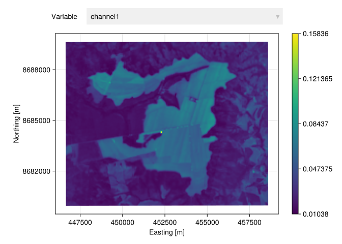

```julia
img = image |> Proj(utmsouth(22))

img |> viewer
```

**Note**

The UTM zone `22` was obtained from the longitude coordinate of the centroid of the domain via the formula

```julia
lon = coords(centroid(image.geometry)).lon

frac = ustrip((lon + 183u"°") / 6)

zone = round(Int, frac)
```

```
22
```

The corresponding latitude coordinate is negative, meaning the domain is in the `:south` hemisphere. Hence, `utmsouth(22)` was selected as the target `CRS`.

## 13.2 Objectives

Our objective is twofold. First, we would like to assign a categorical value for each pixel of the image, which is true inside of the agricultural field and false outside. This value (a.k.a. label) can be useful in applications of [geostatistical learning](https://www.frontiersin.org/articles/10.3389/fams.2021.689393/full). Second, we would like to convert the region of the image that is inside of the agricultural field into a polygonal area for measurements of area and perimeter.

## 13.3 Methodology

In order to assign meaning to the pixels of the image, we first need to visualize the land as if we were looking at it with our naked eyes. Then, we can highlight some regions of the image based on selected formulas— [spectral indices](https://awesome-ee-spectral-indices.readthedocs.io/en/latest)— computed with the spectral bands measured by the Sentinel-2 satellite. Finally, we can introduce a threshold for the values of the indices to obtain a categorical variable and extract polygonal areas of interest.

The proposed methodology has the following steps:

1. Visualization of land in familiar color space
2. Identification of useful spectral indices
3. Segmentation of image based on threshold
4. Measurement of area and perimeter of field

### 13.3.1 Visualization of land

The Sentinel-2 dataset stores the red (`R`), green (`G`) and blue (`B`) bands in the 4th, 3rd and 2nd channels of the image:

```julia
rgb = img |> Select(4 => "R", 3 => "G", 2 => "B")
```

132265 rows omitted

| 132275×4 GeoTable over 407×325 TransformedGrid R Continuous [NoUnits] | 132275×4 GeoTable over 407×325 TransformedGrid G Continuous [NoUnits] | 132275×4 GeoTable over 407×325 TransformedGrid B Continuous [NoUnits] | 132275×4 GeoTable over 407×325 TransformedGrid geometry Quadrangle 🖈 TransverseMercator{WGS84Latest} |
| --- | --- | --- | --- |
| 0.05734 | 0.06166 | 0.03542 | Quadrangle((x: 4.4664e5 m, y: 8.68963e6 m), ..., (x: 4.4664e5 m, y: 8.6896e6 m)) |
| 0.06556 | 0.05936 | 0.03786 | Quadrangle((x: 4.46669e5 m, y: 8.68963e6 m), ..., (x: 4.4667e5 m, y: 8.6896e6 m)) |
| 0.06214 | 0.05824 | 0.03482 | Quadrangle((x: 4.46699e5 m, y: 8.68963e6 m), ..., (x: 4.46699e5 m, y: 8.6896e6 m)) |
| 0.04396 | 0.05254 | 0.02808 | Quadrangle((x: 4.46728e5 m, y: 8.68963e6 m), ..., (x: 4.46728e5 m, y: 8.6896e6 m)) |
| 0.0274 | 0.04538 | 0.0221 | Quadrangle((x: 4.46758e5 m, y: 8.68963e6 m), ..., (x: 4.46758e5 m, y: 8.6896e6 m)) |
| 0.04778 | 0.06664 | 0.03168 | Quadrangle((x: 4.46787e5 m, y: 8.68963e6 m), ..., (x: 4.46787e5 m, y: 8.6896e6 m)) |
| 0.0395 | 0.06036 | 0.02788 | Quadrangle((x: 4.46816e5 m, y: 8.68963e6 m), ..., (x: 4.46816e5 m, y: 8.6896e6 m)) |
| 0.0577 | 0.07608 | 0.0396 | Quadrangle((x: 4.46846e5 m, y: 8.68963e6 m), ..., (x: 4.46846e5 m, y: 8.68961e6 m)) |
| 0.03464 | 0.05336 | 0.02618 | Quadrangle((x: 4.46875e5 m, y: 8.68963e6 m), ..., (x: 446875.0 m, y: 8.68961e6 m)) |
| 0.0339 | 0.05254 | 0.0258 | Quadrangle((x: 4.46904e5 m, y: 8.68963e6 m), ..., (x: 4.46904e5 m, y: 8.68961e6 m)) |
| ⋮ | ⋮ | ⋮ | ⋮ |

We create an auxiliary function that takes the individual channels as inputs and produces a color object from Colors.jl as the output. We use an intensity parameter $\lambda$ to scale the channels and lighten up the image:

```julia
λ = 5 # intensity parameter

ascolor(r, g, b) = RGB(λ * r, λ * g, λ * b)
```

```
ascolor (generic function with 1 method)
```

We can map the function to all the pixels of the image using the `Map` transform:

```julia
color = rgb |> Map(["R", "G", "B"] => ascolor => "RGB")
```

132265 rows omitted

| 132275×2 GeoTable over 407×325 TransformedGrid RGB Colorful [NoUnits] | 132275×2 GeoTable over 407×325 TransformedGrid geometry Quadrangle 🖈 TransverseMercator{WGS84Latest} |
| --- | --- |
| RGB{Float32}(0.2867, 0.3083, 0.1771) | Quadrangle((x: 4.4664e5 m, y: 8.68963e6 m), ..., (x: 4.4664e5 m, y: 8.6896e6 m)) |
| RGB{Float32}(0.3278, 0.2968, 0.1893) | Quadrangle((x: 4.46669e5 m, y: 8.68963e6 m), ..., (x: 4.4667e5 m, y: 8.6896e6 m)) |
| RGB{Float32}(0.3107, 0.2912, 0.1741) | Quadrangle((x: 4.46699e5 m, y: 8.68963e6 m), ..., (x: 4.46699e5 m, y: 8.6896e6 m)) |
| RGB{Float32}(0.2198, 0.2627, 0.1404) | Quadrangle((x: 4.46728e5 m, y: 8.68963e6 m), ..., (x: 4.46728e5 m, y: 8.6896e6 m)) |
| RGB{Float32}(0.137, 0.2269, 0.1105) | Quadrangle((x: 4.46758e5 m, y: 8.68963e6 m), ..., (x: 4.46758e5 m, y: 8.6896e6 m)) |
| RGB{Float32}(0.2389, 0.3332, 0.1584) | Quadrangle((x: 4.46787e5 m, y: 8.68963e6 m), ..., (x: 4.46787e5 m, y: 8.6896e6 m)) |
| RGB{Float32}(0.1975, 0.3018, 0.1394) | Quadrangle((x: 4.46816e5 m, y: 8.68963e6 m), ..., (x: 4.46816e5 m, y: 8.6896e6 m)) |
| RGB{Float32}(0.2885, 0.3804, 0.198) | Quadrangle((x: 4.46846e5 m, y: 8.68963e6 m), ..., (x: 4.46846e5 m, y: 8.68961e6 m)) |
| RGB{Float32}(0.1732, 0.2668, 0.1309) | Quadrangle((x: 4.46875e5 m, y: 8.68963e6 m), ..., (x: 446875.0 m, y: 8.68961e6 m)) |
| RGB{Float32}(0.1695, 0.2627, 0.129) | Quadrangle((x: 4.46904e5 m, y: 8.68963e6 m), ..., (x: 4.46904e5 m, y: 8.68961e6 m)) |
| ⋮ | ⋮ |

The `viewer` displays the colors and reveals the features of the land:

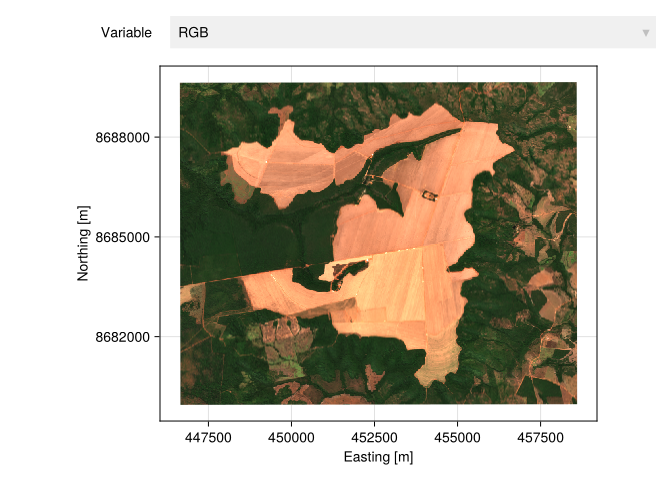

```julia
color |> viewer
```

The agricultural field of interest is displayed in orange color, surrounded by green vegetation.

### 13.3.2 Spectral indices

Given that the image is made of two groups of vegetation (green vs. orange), we lookup all the `spectralindices` that are adequate for the application. We print the first 20 vegetation indices along with their short and long names:

```julia
isvegetation(ind) = ind.application_domain == "vegetation"

inds = filter(isvegetation, spectralindices())

for ind in first(inds, 20)
  println(ind.short_name, ": ", ind.long_name)
end
```

```
KDI: Kochia Detection Index
RI: Redness Index
TTVI: Transformed Triangular Vegetation Index
mSR705: Modified Simple Ratio (705 and 445 nm)
DSWI1: Disease-Water Stress Index 1
NIRvH2: Hyperspectral Near-Infrared Reflectance of Vegetation
sNIRvSWIR: SWIR-enhanced Near-Infrared Reflectance of Vegetation
TRRVI: Transformed Red Range Vegetation Index
STI4RE: 4-band Red Edge Soil Tillage Index
VI700: Vegetation Index (700 nm)
OCVI: Optimized Chlorophyll Vegetation Index
STI: Simple Tillage Index
GBNDVI: Green-Blue Normalized Difference Vegetation Index
GDVI: Generalized Difference Vegetation Index
GARI: Green Atmospherically Resistant Vegetation Index
DVI: Difference Vegetation Index
RDVI: Renormalized Difference Vegetation Index
NIRvP: Near-Infrared Reflectance of Vegetation and Incoming PAR
SNDTI: Soil-Adjusted Normalized Difference Tillage Index
ARI: Anthocyanin Reflectance Index
```

Each of these indices is computed with specific `spectralbands`. Consider the `"NDVI"` vegetation index as an example. It is computed in terms of the red (`R`) and near-infrared (`N`) bands:

```julia
for band in spectralbands("NDVI")
  println(band.short_name, ": ", band.long_name)
end
```

```
N: Near-Infrared (NIR)
R: Red
```

The `R` band was already selected above for the visualization of the land. The `N` band is stored in the 8th channel of the image:

```julia
n = img |> Select(8 => "N")
```

132265 rows omitted

| 132275×2 GeoTable over 407×325 TransformedGrid N Continuous [NoUnits] | 132275×2 GeoTable over 407×325 TransformedGrid geometry Quadrangle 🖈 TransverseMercator{WGS84Latest} |
| --- | --- |
| 0.2495 | Quadrangle((x: 4.4664e5 m, y: 8.68963e6 m), ..., (x: 4.4664e5 m, y: 8.6896e6 m)) |
| 0.22478 | Quadrangle((x: 4.46669e5 m, y: 8.68963e6 m), ..., (x: 4.4667e5 m, y: 8.6896e6 m)) |
| 0.22256 | Quadrangle((x: 4.46699e5 m, y: 8.68963e6 m), ..., (x: 4.46699e5 m, y: 8.6896e6 m)) |
| 0.2388 | Quadrangle((x: 4.46728e5 m, y: 8.68963e6 m), ..., (x: 4.46728e5 m, y: 8.6896e6 m)) |
| 0.2832 | Quadrangle((x: 4.46758e5 m, y: 8.68963e6 m), ..., (x: 4.46758e5 m, y: 8.6896e6 m)) |
| 0.3032 | Quadrangle((x: 4.46787e5 m, y: 8.68963e6 m), ..., (x: 4.46787e5 m, y: 8.6896e6 m)) |
| 0.28744 | Quadrangle((x: 4.46816e5 m, y: 8.68963e6 m), ..., (x: 4.46816e5 m, y: 8.6896e6 m)) |
| 0.37326 | Quadrangle((x: 4.46846e5 m, y: 8.68963e6 m), ..., (x: 4.46846e5 m, y: 8.68961e6 m)) |
| 0.2854 | Quadrangle((x: 4.46875e5 m, y: 8.68963e6 m), ..., (x: 446875.0 m, y: 8.68961e6 m)) |
| 0.28958 | Quadrangle((x: 4.46904e5 m, y: 8.68963e6 m), ..., (x: 4.46904e5 m, y: 8.68961e6 m)) |
| ⋮ | ⋮ |

We can compute the `"NDVI"` spectral index with the `SpectralIndex` transform by providing a geotable with all the necessary bands:

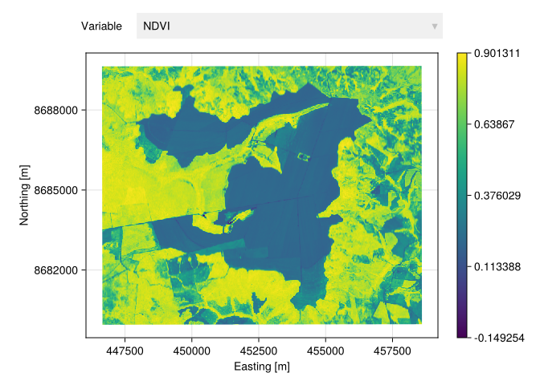

```julia
ndvi = [rgb n] |> SpectralIndex("NDVI")

ndvi |> viewer
```

We see that the index assigns values close to one to pixels with green vegetation and values close to zero inside the agricultural field. Let’s compare this result with other spectral indices. The `"MGRVI"` and `"SI"` indices are also computed in terms of the `R`, `G` and `B` bands:

```julia
mgrvi = [rgb n] |> SpectralIndex("MGRVI")
si = [rgb n] |> SpectralIndex("SI")

spec = [ndvi mgrvi si]
```

132265 rows omitted

| 132275×4 GeoTable over 407×325 TransformedGrid NDVI Continuous [NoUnits] | 132275×4 GeoTable over 407×325 TransformedGrid MGRVI Continuous [NoUnits] | 132275×4 GeoTable over 407×325 TransformedGrid SI Continuous [NoUnits] | 132275×4 GeoTable over 407×325 TransformedGrid geometry Quadrangle 🖈 TransverseMercator{WGS84Latest} |
| --- | --- | --- | --- |
| 0.626255 | 0.0725095 | 0.948457 | Quadrangle((x: 4.4664e5 m, y: 8.68963e6 m), ..., (x: 4.4664e5 m, y: 8.6896e6 m)) |
| 0.548392 | -0.0990195 | 0.945666 | Quadrangle((x: 4.46669e5 m, y: 8.68963e6 m), ..., (x: 4.4667e5 m, y: 8.6896e6 m)) |
| 0.56347 | -0.0647269 | 0.94819 | Quadrangle((x: 4.46699e5 m, y: 8.68963e6 m), ..., (x: 4.46699e5 m, y: 8.6896e6 m)) |
| 0.689065 | 0.176429 | 0.95842 | Quadrangle((x: 4.46728e5 m, y: 8.68963e6 m), ..., (x: 4.46728e5 m, y: 8.6896e6 m)) |
| 0.823567 | 0.465671 | 0.968322 | Quadrangle((x: 4.46758e5 m, y: 8.68963e6 m), ..., (x: 4.46758e5 m, y: 8.6896e6 m)) |
| 0.727734 | 0.320943 | 0.951193 | Quadrangle((x: 4.46787e5 m, y: 8.68963e6 m), ..., (x: 4.46787e5 m, y: 8.6896e6 m)) |
| 0.758365 | 0.400317 | 0.957325 | Quadrangle((x: 4.46816e5 m, y: 8.68963e6 m), ..., (x: 4.46816e5 m, y: 8.6896e6 m)) |
| 0.732226 | 0.269689 | 0.942089 | Quadrangle((x: 4.46846e5 m, y: 8.68963e6 m), ..., (x: 4.46846e5 m, y: 8.68961e6 m)) |
| 0.783527 | 0.407035 | 0.961873 | Quadrangle((x: 4.46875e5 m, y: 8.68963e6 m), ..., (x: 446875.0 m, y: 8.68961e6 m)) |
| 0.790404 | 0.412118 | 0.962521 | Quadrangle((x: 4.46904e5 m, y: 8.68963e6 m), ..., (x: 4.46904e5 m, y: 8.68961e6 m)) |
| ⋮ | ⋮ | ⋮ | ⋮ |

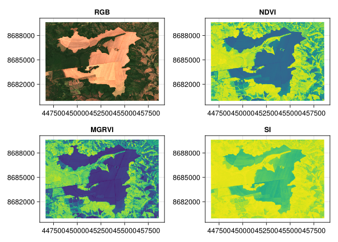

```julia
fig = Mke.Figure()
ax1 = Mke.Axis(fig[1, 1], title = "RGB")
ax2 = Mke.Axis(fig[1, 2], title = "NDVI")
ax3 = Mke.Axis(fig[2, 1], title = "MGRVI")
ax4 = Mke.Axis(fig[2, 2], title = "SI")
viz!(ax1, color.geometry, color = color.RGB)
viz!(ax2, spec.geometry, color = spec.NDVI)
viz!(ax3, spec.geometry, color = spec.MGRVI)
viz!(ax4, spec.geometry, color = spec.SI)
fig
```

### 13.3.3 Image segmentation

From visual inspection, we select the `"MGRVI"` index for image segmentation. It produces a strong contrast between pixels that are inside and outside the agricultural field. We use the `Map` transform again to create a binary variable in terms of the 30th percentile of the spectral index:

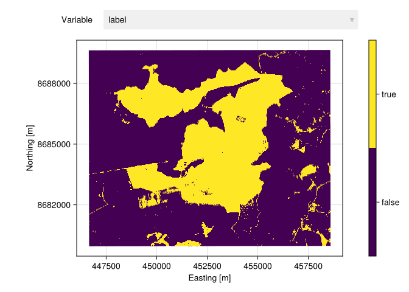

```julia
q30 = quantile(mgrvi.MGRVI, 0.3)

isinside(x) = x < q30

binary = mgrvi |> Map("MGRVI" => isinside => "label")

binary |> viewer
```

Additionally, we use the `ModeFilter` transform to eliminate small artifacts that are not relevant for our stated objectives:

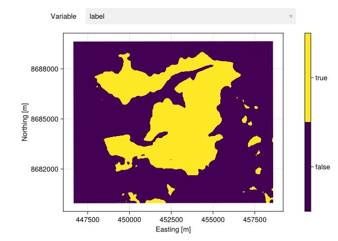

```julia
mask = binary |> ModeFilter()

mask |> viewer
```

The first objective has been achieved. The resulting labels can be used in supervised learning tasks with the `Learn` transform and any subset of spectral bands.

### 13.3.4 Geometric measurements

For the second objective, we use the `Potrace` transform to extract polygonal areas from the image based on the labels of the previous section:

```julia
potrace = mask |> Potrace("label")
```

| 2×2 GeoTable over 2 GeometrySet label Categorical [NoUnits] | 2×2 GeoTable over 2 GeometrySet geometry MultiPolygon 🖈 TransverseMercator{WGS84Latest} |
| --- | --- |
| false | Multi(9×Pgon) |
| true | Multi(39×Pgon) |

We can visualize the region where the label is `true`:

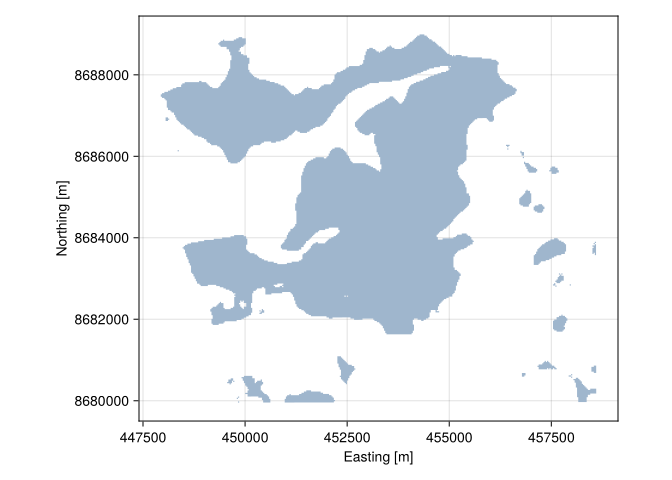

```julia
region = potrace.geometry[findfirst(potrace.label)]

region |> viz
```

It is made of various polygons of different size. Our agricultural field is the polygon with largest area:

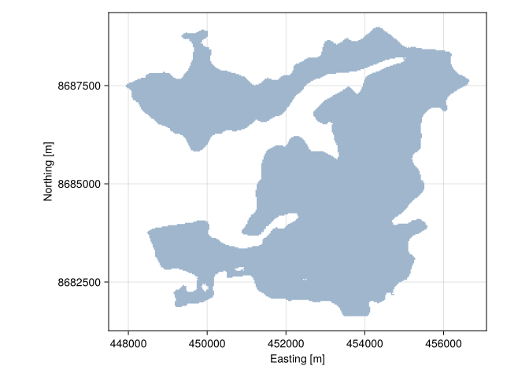

```julia
polys = parent(region)

field = argmax(area, polys)

field |> viz
```

It has an area of approximately

```julia
area(field) |> u"ha"
```

```
3218.212510515785 ha
```

and a perimeter of approximately

```julia
perimeter(field) |> u"km"
```

```
73.62470740120312 km
```

## 13.4 Summary

In this chapter, we illustrated an application of the framework in the agriculture industry. Among other things, we learned how to

- Compute spectral indices to highlight geospatial objects of interest in satellite images.
- Extract objects from categorical labels to perform measurements of area and perimeter.

The tools presented here are useful in various other geostatistical applications involving remote sensing data. As an advanced geospatial data scientist, you will need to integrate data from different satellite missions to improve your understanding of the problem and to propose innovative solutions that cannot be derived from a single data source.